# VISION ZERO - Motor Vehicle Collisions - Crashes

# Did the COVID 19 affect the number of traffic accidents?

## Yearly development

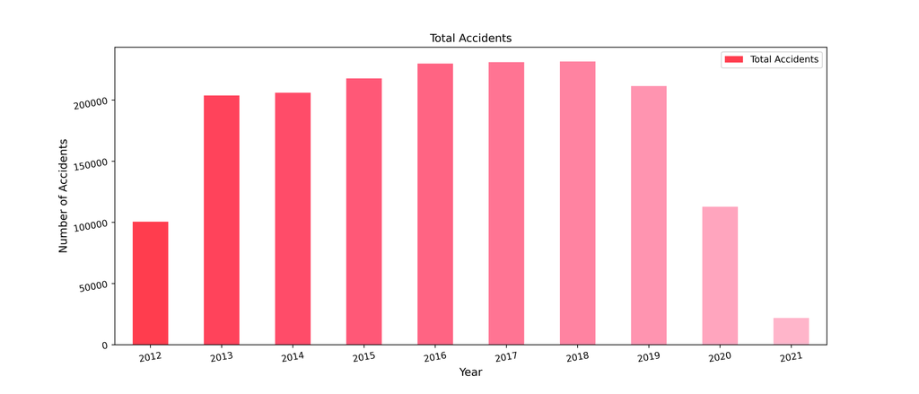

```python
from IPython.display import display, Image
display(Image(filename='TotalAcci1221.png'))
```

As the goal *Vision Zero* was to decrease the number of unnecessary injuries and deaths, it would be eminent that injury and fataility rate dropped as well:

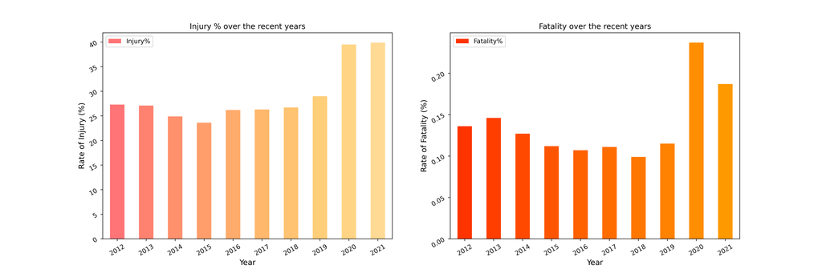

```python
display(Image(filename='injfat1221.png'))
```

By looking the injurys to the left, the number of injuries relevative to the number of accident are somewhat staple, around 25-30%, with a sligth decrease from 13-15, which the rises agai from 2016. Interestring is the number of injuries and fatalities in accidents compared to non harmful accidents, where it can be seen, there was a substainal increase, around 10% points for injuries, and almost a 100% in 2020 for fatalities. So even though there has been fewer accidents, the rate of fatatily has increased signifacant, which is worrysome.  
This could be due to lesser and smaller accidents occuring less frequently, due to less traffic, thus only serious injuries due occur. This, upheld with the contribution factors, this trend is investigated further below:

```python
IFrame(src='./year_all_causes.html', width=950, height=700)
```

[interactive chart not shown]

By comparing these two plots, together with the knowlegde of increasing fataility the last couple of years, it can observed that Speeding, play a vital factor in this trend. This factors have been increasing the last couple of years, which could explain the rise in fataility ratio. By looking the the graph below, this point is further underlined, as speeding is one of the top contributors for fataility.

```python
IFrame(src='./distibution_causes_all.html', width=1000, height=700)
```

[interactive chart not shown]

Since lesser traffic allow for smoother traffic, it likely that speeding more often occur, thus it is important that city of New York continue to figth speeding, as this has been on the rise, and is of the major contributors for fataility.

# Accident serverity increases during the nigth

An interstring takeaway from these plots are that accidents are more prone to injury and fatality during the night, which grows substantially during the early hours of the morning. A topic, which will be investigated further throughtout this notebook

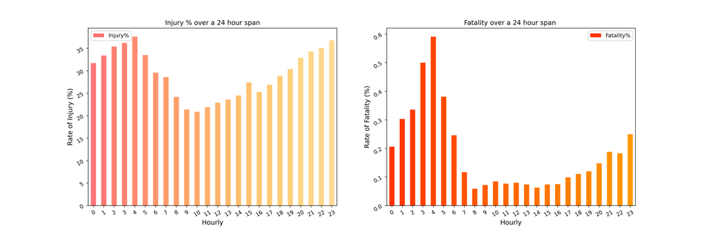

```python
display(Image(filename='injfathourly.png'))
```

# Soft Road Users are more exposed to accidents than counterparties on the road

As stated from Section 1, soft road user are one of the main focuses, on this notebook, which may seem obscure, but by investigating how the soft roads users as bikes and pedestrians are involved in accident, it became evident, that the face a higher risk, especially counterparty risk, i.e. risk which is not self inflicted, meaning other drivers causes harm to them, which is shown in the plot below

```python
IFrame(src='./injury_fatal1.html', width=950, height=700)
```

[interactive chart not shown]

```python
IFrame(src='./injury_fatal3.html', width=950, height=700)
```

[interactive chart not shown]

```python
IFrame(src='./causes_frequency_datasets.html', width=1000, height=700)
```

[interactive chart not shown]

From the plot above, it is quite clear, that especially factors as Failure to Yield Rigth, as Driver Inattion, causes alot of accidents, in particular for cyclist and pedestrians, as these are more present, than the average number of accident in general. Consequently, these are contribution factors to accidents that should be investigated in further details.

# Failure to Yield Rigth and Driver Awareness

As can be seen from the plot above, driver distractions and failure to yield right are common accidents occurring for pedestrians and cyclist, thus putting them in huge counterparty risk, especially for pedestrians, as these two factors contribute to almost 50% of all of accidents. For cyclist, these two factors contribute in approximately 35% of the accidents. For ‘Failure to yield right’ it is relevant to see which crosses are represented most times in the accident statistics. The most represented crosses would be places of interest for further inspection to see if street design could be improved in the crosses to prevent future accidents. Similarly, the ‘Driver Inattention/Distraction’ factor is also relevant to investigate further to see if any locations distract drivers more often. An analysis of the most common locations for these two contributing factors are carried out based on accidents involving a pedestrian or a cyclist.

### Failure to Yield Rigth

By knowing which causes are the main contributors putting bikes and pedestrians in exstensive risk, this knowlegde can be utilized to provide a map, of which intersections are in need of an update, in terms of design or more awareness among drivers:

```python
IFrame(src='./worst_yield_right.html', width=1000, height=700)
```

[interactive chart not shown]

As can be seen there are serveral hotspots, from which it accidents more often occur, like in Queens around flushing main street, where a lot of failure to yield rigth accidents occur. Also around Brooklyn, Tillary Street and Myrtle street alot of accidents to occur. These areas should be investiaged, by the city of New York to determine why drivers fail to yield rigth, and how it could be improved, as these are potential hot spots for accidents, that could have been avoided.

### Driver distraction

```python
IFrame(src='./worst_driver_distraction.html', width=1000, height=700)
```

[interactive chart not shown]

As can be seen from driver distraction, the most dangerous parts of town for pedestrians and cyclist are mostly located wihtin Manhatten, especially in the exit around Queensboro bridge, where alot of distractions causes accidents. Another area is around Noho and China town, and especially the crossof Kenmare Street and Chrystie street is a dangerous intersection, as this section is both high in Driver Distraction and Failure to Yield Rigth

### Subconclusion

Both causes can be seen on the maps, to be centered around different spots throughout the city. This can then be utilizied, by the city of New York to create awareness of the danger of these areas and intersection. Though it could be argueded, that failure to yield rigth, and driver distractions is subjective to the driver, the maps above demostrates, that certain areas and intersections are more prone to accidents than other. This underlines the fact that accidents due occur due to failure of street design, which then can be used by the city of New York to update their current street design.

# Other relevent Contribution Factors for Accidents

As stated from the plot above, two major factors are play a vital part in terms of accidents for soft road users. A interstring perspective was to investigate if any of these accidents, where more prone to occur during certain peak hours. As the plots demostrating below, certain accidents, are more likely to happen during certain hours, some of which make untuitively sense, where as others requires a deeper dive

```python
IFrame(src='./hour_pedestrian_causes.html', width=950, height=700)
```

[interactive chart not shown]

```python
IFrame(src='./hour_cyclist_causes.html', width=950, height=700)
```

[interactive chart not shown]

From the plots there are certain take aways that are interstring. One of the being that *Pavement Slippery* mostly occurs during sunrise and sunset, which makes sense, but is still quite interstring. Same tendency is observed for *Glare*, as this mostly happen during the morning hours. A very interstring takeaway is accident happening due to *Alcohol Involvment*, as this mainly happens during the nigth, and not as much during the day. Rembering the Section 1, as injuries and fatailites were had higher rates as well during the night, thus indicating, that there could be a correlation, which will be investigated further

# The Dangers of Drunk Driving

Drunk driving is known cause of accidents in New York, and something the city, and US in general have tried to cut down on. This section will investiage, how the devolopment of drunk driving has been the last couple of years, as well non volentary inidivduals being effected by drunk driving. Is it only the driver him self, or do the accidents cause harm to others as well?

## For cyclists

```python
IFrame(src='./distibution_causes_cyclist.html', width=1000, height=700)
```

[interactive chart not shown]

One of the reasons for alcohol invovolment, is an interestring topic, is due to its high fataility rate. As can be seen on the plot above, it is the most fatal type of accidents, causing a fataility in roughly 5% of the accidents, and injury in 80%. Luckily it only contributes for around 1% of the accidents, but it is still af factor that needs to be mitigated. As stated cyclist and pedestrins are in greater risk of counterparty failure or accidents, thus the following plots illustrates the cotribution factors for cyclist over a 24 hour span. From the plot it can be derived, that accidents occuring to cyclists are most common during the nigth, as well as during the weekend

```python
IFrame(src='./hour_cyclist_causes.html', width=950, height=700)
```

[interactive chart not shown]

```python
IFrame(src='./weekday_cyclist_causes.html', width=950, height=700)
```

[interactive chart not shown]

So accidents for cyclist involving drunk driving are most commonly during the nigth, as well during the weekend. Consequetly it would be expected that cyclists are in most danger of being killed in traffic, during the weekend nights:

[figure not shown]

```python
display(Image(filename='injfathourlypdcy.png'))
```

## For pedestrians

```python
IFrame(src='./distibution_causes_pedestrians.html', width=1000, height=700)
```

[interactive chart not shown]

The same tendency is clear for pedestrians, but only intensified. Alchohol involvment is the major contributor for pedestrian fatalities, which must be adressed in order to reduce the number of fatalities. By comparison, ancidents invovling alcohol only make contribute to roughly 1%, yet of all accidents for both pedestians as cyclist, thus making an important factor to mitigate, and decrease, in order to avoid unnecessary fatailities. Moreover traffic control disregard, and speeding are some of the major factors for fatalities, and these factors should be mitigated as well in order to avoid further unnecessary accidents.

Moreover as was seen from accidents involving cyclists, alcohol accidents affecting pedestrians, does also mostly take place during the night, as well as during the weekend, as the figure below demostrate. In terms of speeding and disobyeing traffic controls, those factors occur more often durig the day, as well as during the midweek.

```python
IFrame(src='./hour_pedestrian_causes.html', width=950, height=700)
```

[interactive chart not shown]

```python
IFrame(src='./weekday_pedestrian_causes.html', width=950, height=700)
```

[interactive chart not shown]

As can be seen accidents involving pedestrians are most likely to occur during late afternoon nigth and especially in the weekend, as the plots above demostrates. Thus pedestrians have increased risk of being involved in an accident during those hours, and are in more danger of fatality, which is underlined in the plot below. Moreover it can be observe, that almost every time a pedestrian is invovled in an accidentn, no matter the hour, it almost always results in injury.

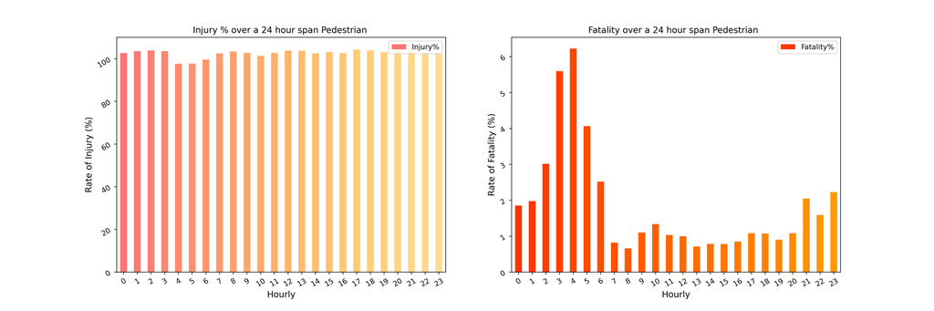

```python
display(Image(filename='injfathourlypdcy.png'))
```

## Summary

The consumption of alcohol and rate of accidents for bike and pedestrians, was especially a problem in the beginning of 2016, as can be seen from the figures above, which has luckly declined since.An interstring outtake, as this has since declined, throughout the years, which can partly be due to their sobriety-checkpoints, and their increased focus on drunk driving. [4]. Moreover pedestrians and cyclist are in imminent danger of fataility and injury in certain peaks hours due to drunk drivers, which is located during the nigth, and especially in the weekends.

# Does weather influence accidents?

Another interstring point derived from the data, was that weather conditions do play a part in terms of accidents. diffucult weather conditions, results in more injuries and fatailities, but only for pedestrians.

Interestringly enough, the amount of accidents, injuries or deaths, does not increase for cyclist as a consequence of weather conditions, which was the initial thoughth.By comparing data it was observed that accidents on bikes occur mostly in the time spans with good weather, during summers. This intuitively is logic, since riding a bike in the winther or during bad weather is unpleasent, and is often avoided.

For pedestrians on the other hand, it the tendency was clear as shown below:

```python
display(Image(filename='weather_inj_fat_rateped.png'))
```

[figure not shown]

From this graph it can be observed, that weather conditions do play a vital part in when pedestrians are most likely to be injured or killed in traffic. As can be seen from the graphs above, that even though dry roads is the most common of weather conditions for accidents, injuries and deaths, the most dangerous conditions in terms of injuries, wet and snowy roads, as these pose a great prone to injruies among pedestrians. In terms of fatalities, heavy wet road, is the most dangerous one, with a average fataility per day of 0.2, though closely followed by dry road +. In terms of contribution reasons it can also be observed, than increanly bad weather causes more accidents in particular within the major contribution factors as Failure to Yield Rigth and Driver Distraction, as shown below

```python
IFrame(src='./avg_causes_frequency_weather.html', width=950, height=700)
```

[interactive chart not shown]

From the analysis of pedestrians and cyclist, the following can be concluded:

Most interstring takeaways from the analysis is the hours of which soft road users are most prone to fatality, but especially the contribution factors. Remebering the motivation for the project, was to provide an overview, where, when and why accidents occured, and moreover to provide the city of New York with a tools and insights to utilized to update current street design. By using the knowlegde of the contribution factors, this is then further linked, with where these accidents takes place, which then will be pint pointed out, thus providing the where, to which street designs should be updated.

# Appendix

```python
from __future__ import (absolute_import, division, print_function)
import json
import pandas as pd
import requests
import numpy as np
import html
import folium
import copy
from folium import plugins
from folium.plugins import HeatMap, TimeSliderChoropleth, MarkerCluster, HeatMapWithTime
import matplotlib.pyplot as plt
from matplotlib import cm
import matplotlib as mpl
from bokeh.models import ColumnDataSource, FactorRange
from bokeh.io import output_file, show
from bokeh.palettes import GnBu3, OrRd3, Category20,Category10, Spectral6
from bokeh.plotting import figure, output_file, save
from bokeh.transform import factor_cmap
from collections import Counter
import googlemaps
from datetime import datetime
import geopandas as gpd
import os
import plotly.express as px
import plotly.graph_objs as go
import plotly.offline as offline
from plotly.graph_objs import *
from plotly.offline import download_plotlyjs, init_notebook_mode, plot, iplot
from shapely.geometry import Point, Polygon
from geopandas import GeoSeries, GeoDataFrame
import contextily as ctx
from ipywidgets import interact, interactive, fixed, interact_manual
import ipywidgets as widgets
%matplotlib inline

#df = pd.read_csv('data_preparred.csv',low_memory=False)
#df['datetime']=pd.to_datetime(df['CRASH DATE'] + ' ' + df['CRASH TIME'])
#df.datetime = pd.to_datetime(df.datetime, format='%Y-%m-%d %H:%M:%S')
#df['month'] = df.datetime.apply(lambda x: x.month)
#df['week'] = df.datetime.apply(lambda x: x.week)
#df['day'] = df.datetime.apply(lambda x: x.day)
#df['hour'] = df.datetime.apply(lambda x: x.hour)
#df['year']= df.datetime.apply(lambda x: x.year)
#df['day_of_week'] = df['datetime'].dt.dayofweek

dfcyclemergedtime=df


fp = 'ZIP_CODE_040114.shp'
zip_geo = gpd.read_file(fp)
zip_geo.rename(columns = {'ZIPCODE':'ZIP CODE'}, inplace = True)

dfcyclegrouptime=dfcyclemergedtime.groupby(['ZIP CODE','hour'], as_index=False).sum()

dfcyclegrouptime=zip_geo.merge(dfcyclegrouptime,on="ZIP CODE")

dfcyclegrouptime=dfcyclegrouptime[['ZIP CODE','hour','PO_NAME','geometry','COUNTY','NUMBER OF PERSONS INJURED','NUMBER OF PERSONS KILLED']]

nymap1 = folium.Map(location=[40.72, -74.000], zoom_start=11,tiles=None)
folium.TileLayer('CartoDB positron',name="Light Map",control=False).add_to(nymap1)
nymap1

ALL = 'ALL'
def unique_sorted_values_plus_ALL(array):
    unique = array.unique().tolist()
    unique.sort()
    unique.insert(0, ALL)
    return unique
dropdown_year = widgets.SelectionSlider(options = unique_sorted_values_plus_ALL(dfcyclegrouptime.hour))
output_year=widgets.Output()

dropdown_year = widgets.SelectionSlider(options = unique_sorted_values_plus_ALL(dfcyclegrouptime.hour))
output_year=widgets.Output()


#dfcyclegrouptime.to_csv('dfcyclegrouptime.csv', index=False)

def dropdown_year_eventhandler(change):
    output_year.clear_output()
    with output_year:
        nymap1 = folium.Map(location=[40.72, -74.000], zoom_start=11,tiles=None)
        folium.TileLayer('CartoDB positron',name="Light Map",control=False).add_to(nymap1)
        if (change.new == ALL):
            NIL=folium.Choropleth(
                geo_data=dfcyclegrouptime,
                name="injuries",
                data=dfcyclegrouptime,
                columns=["ZIP CODE", "NUMBER OF PERSONS KILLED"],
                key_on="feature.properties.ZIP CODE",
                fill_color="OrRd",
                fill_opacity=0.7,
                line_opacity=0.2,
                legend_name="NUMBER OF PERSONS KILLED",)

            nymap1.add_child(NIL)
            nymap1.keep_in_front(NIL)
            folium.LayerControl().add_to(nymap1)
            #return nymap1
            display(nymap1)
        else:
            dfgeo=dfcyclegrouptime[dfcyclegrouptime.hour == change.new]
            NIL=folium.Choropleth(
                geo_data=dfgeo,
                name="injuries",
                data=dfgeo,
                columns=["ZIP CODE", "NUMBER OF PERSONS KILLED"],
                key_on="feature.properties.ZIP CODE",
                fill_color="OrRd",
                fill_opacity=0.7,
                line_opacity=0.2,
                legend_name="NUMBER OF PERSONS KILLED",
            )
            nymap1.add_child(NIL)
            nymap1.keep_in_front(NIL)
            folium.LayerControl().add_to(nymap1)
            display(nymap1)
            #return nymap1
            #display(dfcyclegrouptime[dfcyclegrouptime.hour == change.new])
            #print(change.new)

dropdown_year.observe(dropdown_year_eventhandler, names='value')
#display(nymap)
outfp = "choropleth_map4.html"
```

[output not shown]

```python
dfcyclemergedtime=df
```

```python
dfcyclegrouptime=dfcyclemergedtime.groupby(['ZIP CODE','hour'], as_index=False).sum()
```

```python
dfcyclegrouptime=zip_geo.merge(dfcyclegrouptime,on="ZIP CODE")
```

```python
dfcyclegrouptime=dfcyclegrouptime[['ZIP CODE','hour','PO_NAME','geometry','COUNTY','NUMBER OF PERSONS INJURED','NUMBER OF PERSONS KILLED']]
```

```python
nymap1 = folium.Map(location=[40.72, -74.000], zoom_start=11,tiles=None)
folium.TileLayer('CartoDB positron',name="Light Map",control=False).add_to(nymap1)
nymap1
```

```python
ALL = 'ALL'
def unique_sorted_values_plus_ALL(array):
    unique = array.unique().tolist()
    unique.sort()
    unique.insert(0, ALL)
    return unique
dropdown_year = widgets.SelectionSlider(options = unique_sorted_values_plus_ALL(dfcyclegrouptime.hour))
output_year=widgets.Output()
```

```python
dropdown_year = widgets.SelectionSlider(options = unique_sorted_values_plus_ALL(dfcyclegrouptime.hour))
output_year=widgets.Output()
```

```python
#dfcyclegrouptime.to_csv('dfcyclegrouptime.csv', index=False)
```

```python
def dropdown_year_eventhandler(change):
    output_year.clear_output()
    with output_year:
        nymap1 = folium.Map(location=[40.72, -74.000], zoom_start=11,tiles=None)
        folium.TileLayer('CartoDB positron',name="Light Map",control=False).add_to(nymap1)
        if (change.new == ALL):
            NIL=folium.Choropleth(
                geo_data=dfcyclegrouptime,
                name="injuries",
                data=dfcyclegrouptime,
                columns=["ZIP CODE", "NUMBER OF PERSONS KILLED"],
                key_on="feature.properties.ZIP CODE",
                fill_color="OrRd",
                fill_opacity=0.7,
                line_opacity=0.2,
                legend_name="NUMBER OF PERSONS KILLED",)

            nymap1.add_child(NIL)
            nymap1.keep_in_front(NIL)
            folium.LayerControl().add_to(nymap1)
            #return nymap1
            display(nymap1)
        else:
            dfgeo=dfcyclegrouptime[dfcyclegrouptime.hour == change.new]
            NIL=folium.Choropleth(
                geo_data=dfgeo,
                name="injuries",
                data=dfgeo,
                columns=["ZIP CODE", "NUMBER OF PERSONS KILLED"],
                key_on="feature.properties.ZIP CODE",
                fill_color="OrRd",
                fill_opacity=0.7,
                line_opacity=0.2,
                legend_name="NUMBER OF PERSONS KILLED",
            )
            nymap1.add_child(NIL)
            nymap1.keep_in_front(NIL)
            folium.LayerControl().add_to(nymap1)
            display(nymap1)
            #return nymap1
            #display(dfcyclegrouptime[dfcyclegrouptime.hour == change.new])
            #print(change.new)

dropdown_year.observe(dropdown_year_eventhandler, names='value')
#display(nymap)
outfp = "choropleth_map4.html"
nymap1.save(outfp)
display(dropdown_year)
display(output_year)
```

```python
import io
from PIL import Image
img_data = nymap1._to_png(5)
img = Image.open(io.BytesIO(img_data))
img.save('0.png')
```